# FQ and R per card - R-PAS’Dataset

## Main Analysis

So the idea was to test whether FQ get worse as the response number increase. For instance, first response to a card would have a better FQ than the second response, which will be better then the third response, which will be better than the four response.

As an extreme scenario we are testing if we have cases like this:

- First response to a card -> FQo (3)
- Second response to a card -> Fqu (2)
- Third response to a card -> Fq- (1)
- Fourth response to a card -> Fqn (0)

given FQo == 3, FQu ==2, FQ- == 1, FQn == 0, we anticipate a negative correlation between the number of the response per card with FQ.

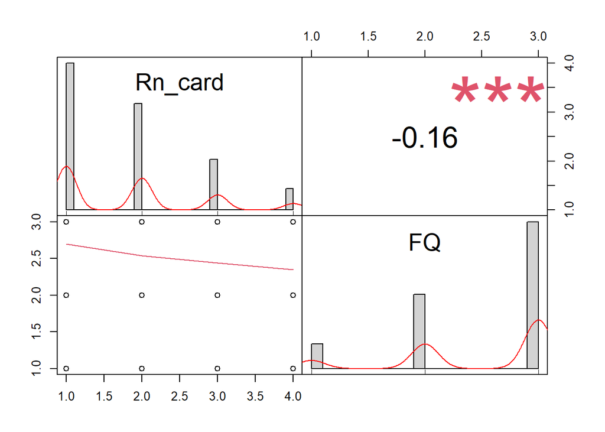

This is the result from rpas dataset, we observed a correlation with *r* = -.16, *p* < .001 , 95%CI[-.19, -.12]. This result go in the same direction and roughly the same magnitude we found on Kline’s dataset (*r* = -.13), and Gi’s dataset (*r* = -.09)

From the scatterplot above, is hard to tell how the association really looks like, because most of the dots are on top of the others, so below, we can see a new scatterplot, presenting the same information as above but dispersing the dots a bit so we can better see the really amount of dots in each quadrant. The shadowy area around the regression line shows the CI.

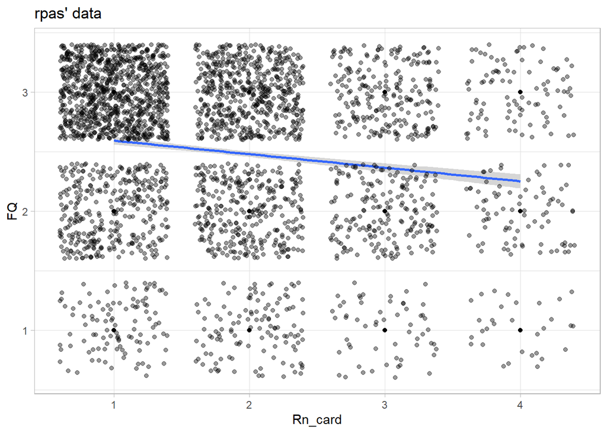

This way we can see that the association is indeed low. However, it is negative, which is in the expected direction.